```python
#!/usr/bin/python
#-*- coding: utf-8 -*-
```

# 基于最优化方法的最佳回归系数确定

优点：计算代价不高，易于理解和实现  
缺点：容易欠拟合，分类精度可能不高  
适用数据类型：数值型、标称型

## 二分类Sigmoid函数

### Sigmoid函数

$$\sigma (z)=\frac{1}{1+e^{-z}}$$

[figure not shown]

类似阶跃函数，而阶跃函数的瞬间跳跃过程在数学上比较难处理  
sigmoid函数在z=0处的取值为0.5，取值范围为0-1  
因此可以将\(\sigma (z) < 0.5\)的结果归为分类0，将\(\sigma (z) > 0.5\)的结果归类为分类1

### Logistic回归

为每个特征\(x_i\)分配一个回归系数（权重）\(wi\)  
只需计算\(\sigma (\sum^{n}{i=0} {w_i \cdot x_i})\)，若小于0.5则分为类0，若大于0.5则分为类1  
记\(z = w_0x_0 + w_1x_1 + w_2x_2 + ... = w^Tx\)  
其中最重要的是找到**回归系数**

### 基于最优化方法的最佳回归系数确定

梯度上升法：查找局部最大值，沿梯度方向探寻，不断逼近实际的最大值
函数\(f(x,y)\)的梯度记为
$$\triangledown f(x,y) = \left( \begin{array}{ccc} \frac{\partial f(x,y)}{\partial x} \\\ \frac{\partial f(x,y)}{\partial y} \end{array} \right)$$
梯度上升算法的迭代公式
$$w := w + \alpha \triangledown_w f(w)$$
其中，w为回归系数向量，\(\alpha\)为步长，\(\triangledown_w\)为梯度，f(w)为待求最大值的函数
类似的，梯度下降算法的迭代公式为\(w := w + \alpha \triangledown_w f(w)\)，用于毕竟最小值
通常采用迭代的方式，直到达到某个条件（如迭代次数达到某个值，或算法达到某个误差范围内）为止

#### 举例（限定迭代次数）

已知一组100个的数据，共3个特征值，构成100x3的矩阵D；以及一组对应的二分类标签向量F（元素为0或1，长度100，假设是列向量）

- 选择算法步长\(\alpha\)和迭代次数n
- 初始化一个回归系数行向量w（通常将各个元素初始化为1）
- 重复n次
  - 根据w计算D和F构成的数据集的梯度
    - 根据w对D每行进行加权求和
      $$D \times w$$
    - 利用sigmoid函数对加权求和的结果进行分类，得到各组的sigmoid值组成的列向量S
    - 计算梯度（误差） $$E = F - S$$
      由于sigmoid函数并不是理想的阶跃函数，其值不完全是0或1，存在一定的误差
  - 迭代计算新的回归系数w $$w := w + \alpha \times D^T \times E$$
- 得到最后的回归系数w

```python
import logRegres
```

```python
dataArr, labelMat = logRegres.loadDataSet()
```

```python
weights = logRegres.gradAscent(dataArr, labelMat)
print weights
```

```
[[ 4.12414349]
 [ 0.48007329]
 [-0.6168482 ]]
```

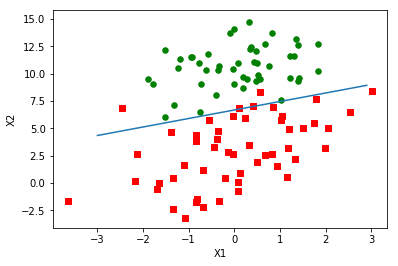

```python
# numpy.martix的getA方法，将矩阵转换为对应的数组返回
logRegres.plotBestFit(weights.getA())
```

### 随机梯度上升算法

梯度上升算法每次更新回归系数都需要遍历一次数据集，当样本、特征数量比较庞大时，计算复杂度会变得非常高；  
可以采用随机梯度上升算法代替，  
随机梯度上升算法每次只用一个样本点来更新回归系数，可以在新样本到来时进行增量式的更新，是一种在线学习算法

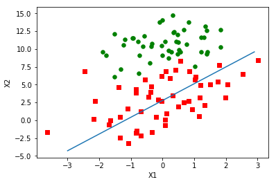

```python
weights = logRegres.stocGradAscent0(np.array(dataArr), labelMat)
logRegres.plotBestFit(weights)
```

分类效果并不是很好

但我们更关注的是——随机梯度上升算法是否收敛？  
运行随机梯度上升算法进行多次迭代——

[figure not shown]

总体上看，三个参数随迭代次数的增加收敛，而且参数X1和X2能较快收敛；  
但曲线存在着明显的局部波动，这不是我们所期望的

### 改进的随机梯度上升算法

- 动态变化的步长\( \alpha \)  
  如取\( \alpha = \frac{4}{1+j+i} + 0.01 \)
  - 0.01为常数项，以确保\( \alpha \)永远不会减小到0，同时保证新加入的样本具有一定的影响，通常样本动态性越强，常数项就取得越大
  - 分子4是控制步长变化大小的因子
  - 分母中i为当前样本的索引号（初始0，每处理一个样本就加一）
  - 分母中j为当前迭代的索引号（初始0，每迭代一次就加一）
  - 分母同时受i和j控制，当\( j < max(i) \)时\( \alpha \)不会出现严格下降  
    避免参数严格下降常见于模拟退火算法等其他优化算法
- 随机取样
  - 避免相邻数据存在一定的相关性而出现周期性波动

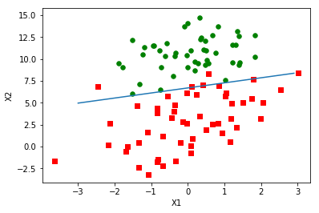

```python
weights = logRegres.stocGradAscent1(np.array(dataArr), labelMat)
logRegres.plotBestFit(weights)
```

分类效果比改进前好得多  
已经很接近梯度上升算法，但计算量却要小的多~

改进后参数随迭代次数的变化：

[figure not shown]

可以看到，局部波动明显改善，而且收敛速度也更快

## 数据缺失处理

### 部分特征值缺失

- 用可用特征的均值来填补缺失值
- 使用特殊值如-1,0等来填补缺失值  
  比如先前出现的梯度上升的迭代公式\(w := w + \alpha \triangledown_w f(w)\)  
  缺失值如果填补特殊值0，则迭代公式对应项变为w := w，也即不影响回归系数的更新
- 忽略有缺失值的样本
- 使用相似样本的均值填补缺失值
- 使用另外的机器学习算法预测缺失值

### 部分标签缺失

一般直接简单地把这些数据丢弃